# ESILV - Python for data analysis - project 2022

Import des modules

```python
import pandas as pd
import numpy as np
import matplotlib.pyplot as plt
import seaborn as sns
from sklearn.model_selection import train_test_split
```

Import des fichiers

The dataset is about bankruptcy prediction of Polish companies. The bankrupt companies were analyzed in the period 2000-2012, while the still operating companies were evaluated from 2007 to 2013. Basing on the collected data five classification cases were distinguished, that depends on the forecasting period: - 1stYear the data contains financial rates from 1st year of the forecasting period and corresponding class label that indicates bankruptcy status after 5 years. - The data contains 7027 instances (financial statements), 271 represents bankrupted companies, 6756 firms that did not bankrupt in the forecasting period.

```python
year1 = pd.read_csv('C:/Users/Suvin/Desktop/Python for DATA/Projet/1year.txt', sep=",", names = list(map( lambda x: f'X{x+2}' ,range(-1,64))))
year1.head()
```

|  | X1 | X2 | X3 | X4 | X5 | X6 | X7 | X8 | X9 | X10 | ... | X56 | X57 | X58 | X59 | X60 | X61 | X62 | X63 | X64 | X65 |
| --- | --- | --- | --- | --- | --- | --- | --- | --- | --- | --- | --- | --- | --- | --- | --- | --- | --- | --- | --- | --- | --- |
| 0 | 0.20055 | 0.37951 | 0.39641 | 2.0472 | 32.351 | 0.38825 | 0.24976 | 1.3305 | 1.1389 | 0.50494 | ... | 0.121960 | 0.39718 | 0.87804 | 0.001924 | 8.416 | 5.1372 | 82.658 | 4.4158 | 7.4277 | 0 |
| 1 | 0.20912 | 0.49988 | 0.47225 | 1.9447 | 14.786 | 0 | 0.25834 | 0.99601 | 1.6996 | 0.49788 | ... | 0.121300 | 0.42002 | 0.85300 | 0 | 4.1486 | 3.2732 | 107.350 | 3.4 | 60.987 | 0 |
| 2 | 0.24866 | 0.69592 | 0.26713 | 1.5548 | -1.1523 | 0 | 0.30906 | 0.43695 | 1.309 | 0.30408 | ... | 0.241140 | 0.81774 | 0.76599 | 0.69484 | 4.9909 | 3.951 | 134.270 | 2.7185 | 5.2078 | 0 |
| 3 | 0.081483 | 0.30734 | 0.45879 | 2.4928 | 51.952 | 0.14988 | 0.092704 | 1.8661 | 1.0571 | 0.57353 | ... | 0.054015 | 0.14207 | 0.94598 | 0 | 4.5746 | 3.6147 | 86.435 | 4.2228 | 5.5497 | 0 |
| 4 | 0.18732 | 0.61323 | 0.2296 | 1.4063 | -7.3128 | 0.18732 | 0.18732 | 0.6307 | 1.1559 | 0.38677 | ... | 0.134850 | 0.48431 | 0.86515 | 0.12444 | 6.3985 | 4.3158 | 127.210 | 2.8692 | 7.898 | 0 |

5 rows × 65 columns

## Observations of the Data

```python
year1.describe()
```

|  | X13 | X19 | X20 | X23 | X30 | X31 | X39 | X42 | X43 | X44 | X49 | X55 | X56 | X58 | X62 | X65 |
| --- | --- | --- | --- | --- | --- | --- | --- | --- | --- | --- | --- | --- | --- | --- | --- | --- |
| count | 7027.000000 | 7027.000000 | 7.027000e+03 | 7027.000000 | 7027.000000 | 7027.000000 | 7027.000000 | 7027.000000 | 7.027000e+03 | 7.027000e+03 | 7027.000000 | 7.027000e+03 | 7.027000e+03 | 7.027000e+03 | 7.027000e+03 | 7027.000000 |
| mean | 2.093345 | 0.462392 | 1.162128e+03 | 0.423610 | 23.568949 | 0.473717 | 0.269342 | 0.263638 | 4.588504e+03 | 3.426404e+03 | -1.367363 | 8.855693e+03 | -1.577367e+02 | 1.587409e+02 | 4.763202e+03 | 0.038566 |
| std | 159.699448 | 30.646874 | 9.315822e+04 | 29.742101 | 1826.847970 | 30.647711 | 27.064231 | 27.071123 | 3.627309e+05 | 2.696211e+05 | 107.717867 | 7.247527e+04 | 1.322125e+04 | 1.322124e+04 | 3.107835e+05 | 0.192571 |
| min | -607.420000 | -622.060000 | 0.000000e+00 | -634.590000 | -149.070000 | -622.060000 | -701.630000 | -701.630000 | 0.000000e+00 | 0.000000e+00 | -9001.000000 | -8.004700e+05 | -1.108300e+06 | -4.194000e-03 | 0.000000e+00 | 0.000000 |
| 25% | 0.038073 | 0.014812 | 1.708300e+01 | 0.011253 | 0.094681 | 0.019233 | 0.012786 | 0.011540 | 6.525600e+01 | 3.387300e+01 | -0.009992 | 9.712000e+01 | 2.031450e-02 | 8.647650e-01 | 4.322250e+01 | 0.000000 |
| 50% | 0.080830 | 0.049966 | 3.561200e+01 | 0.042097 | 0.207130 | 0.056637 | 0.046948 | 0.047783 | 9.461200e+01 | 5.180000e+01 | 0.022759 | 1.604800e+03 | 6.338200e-02 | 9.388100e-01 | 6.850900e+01 | 0.000000 |
| 75% | 0.144955 | 0.104500 | 6.070100e+01 | 0.088314 | 0.365635 | 0.114970 | 0.103375 | 0.102165 | 1.304150e+02 | 7.550250e+01 | 0.075464 | 5.955900e+03 | 1.376950e-01 | 9.820150e-01 | 1.063350e+02 | 0.000000 |
| max | 13315.000000 | 2156.800000 | 7.809200e+06 | 2156.800000 | 152860.000000 | 2156.800000 | 2156.500000 | 2156.800000 | 3.039300e+07 | 2.258400e+07 | 31.639000 | 4.398400e+06 | 1.000000e+00 | 1.108300e+06 | 2.501600e+07 | 1.000000 |

Parts of Brankrupcy company

The X65 column contains: -0 if the company has not bankrupt -1 if it has bankrupt

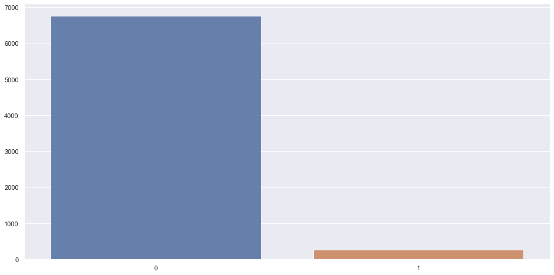

```python
plt.figure(figsize=(16, 8))
count = year1['X65'].value_counts()
sns.set(style="darkgrid")
sns.barplot(count.index, count.values, alpha=0.9)
```

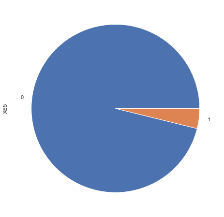

```python
plt.figure(figsize=(15,8))
p =year1["X65"].value_counts().plot(kind='pie')
```

## Data Preprocessing

Error value are replaced by nan

```python
year1= year1.replace("?", np.nan)
```

Values are converted to float

```python
year1 = year1.astype(float)
```

Nan values are replaced by mean imputation

```python
missing = year1.isna().sum() / year1.shape[0] * 100.00
missing_df = pd.DataFrame({'column_name': year1.columns,
                                 '%missing': missing})
missing_df.sort_values('%missing', inplace=True, ascending=False)
missing_df.head()
```

[output not shown]

```python
year1 = year1.apply(lambda x: x.fillna(x.mean()),axis=0)
```

## Data-visualization

selecting some attributs information: X1 net profit / total assets X2 total liabilities / total assets X3 working capital / total assets

```python
year1X1X2X3 = year1[['X1','X2','X3']]
```

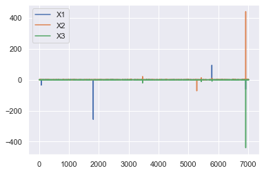

```python
year1X1X2X3.plot()
```

```python
year1_sample = year1X1X2X3[year1X1X2X3.index.isin([1,2,3,4,5])]
```

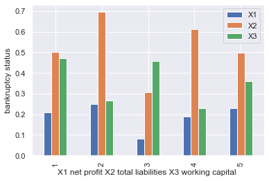

```python
year1_sample.plot(kind='bar', xlabel='X1 net profit X2 total liabilities X3 working capital ', ylabel = 'bankruptcy status')
```

X36 : total sales / total assets

```python
year1X36 = year1['X36']
```

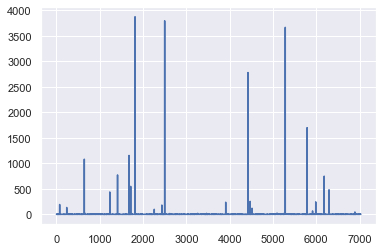

```python
year1X36.plot()
```

X20 : (inventory * 365) / sales

```python
year1X20 = year1['X20']
year1X20_sample = year1X20[year1X20.index.isin([1,2,3,4,5,6,7,8,9,10])]
```

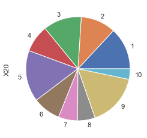

```python
year1X20_sample.plot(kind='pie')
```

X23 net profit / sales

```python
year1X23 = year1['X23']
year1X23_sample = year1X23[year1X23.index.isin([1,2,3,4,5,6,7,8,9,10])]
```

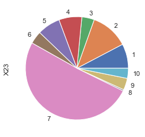

```python
year1X23_sample.plot(kind='pie')
```

## Data Analysis

Correlation Matrix

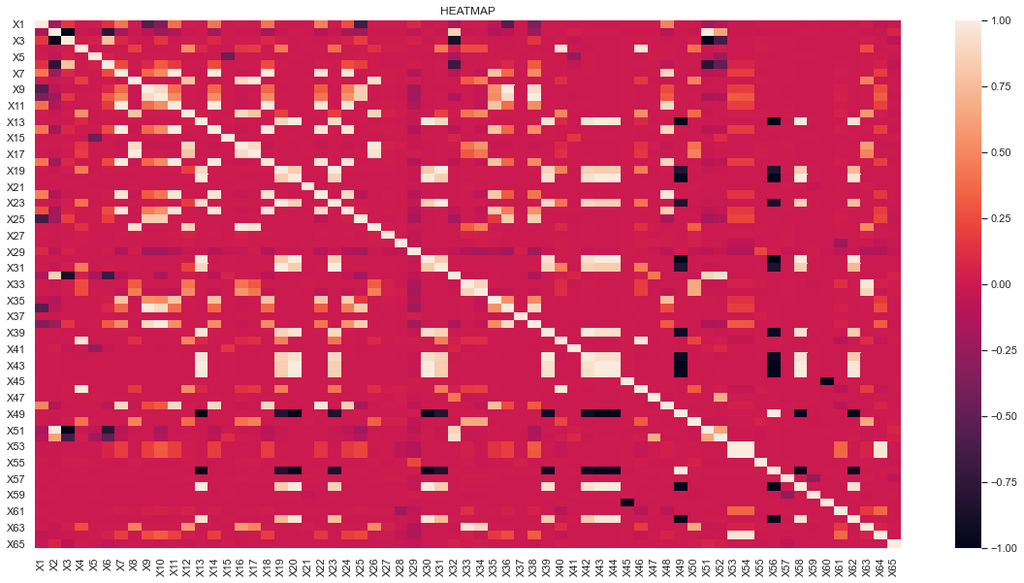

```python
corr=year1.corr()
plt.figure(figsize=(20,10))
ax = plt.axes()
sns.heatmap(corr, ax=ax)
ax.set_title("HEATMAP")
plt.show()
```

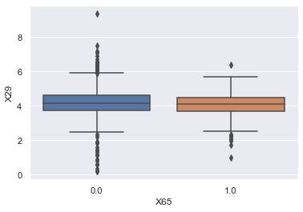

```python
sns.boxplot(x = "X65", y=year1.columns[28], data=year1)
```

Function to find features that a highly positive or negative correlated to other features

```python
def correlation(dataset, threshold):
    col_corr = set()  # Set of all the names of correlated columns
    corr_matrix = dataset.corr()
    for i in range(len(corr_matrix.columns)):
        for j in range(i):
            if abs(corr_matrix.iloc[i, j]) > threshold: # we are interested in absolute coeff value
                colname = corr_matrix.columns[i]  # getting the name of column
                col_corr.add(colname)
    return col_corr

corr_features1 = correlation(year1, 0.60)
```

```python
print("number of feature that we are going to delete from the table :  ",len(corr_features1))
```

```
number of feature that we are going to delete from the table :   41
```

```python
print(corr_features1)
```

```
{'X40', 'X3', 'X18', 'X52', 'X56', 'X6', 'X62', 'X34', 'X54', 'X64', 'X58', 'X22', 'X32', 'X10', 'X26', 'X31', 'X49', 'X16', 'X51', 'X11', 'X50', 'X35', 'X19', 'X20', 'X36', 'X46', 'X39', 'X42', 'X24', 'X30', 'X48', 'X43', 'X12', 'X38', 'X14', 'X25', 'X44', 'X17', 'X63', 'X60', 'X23'}
```

```python
year1.drop(corr_features1,axis=1, inplace=True)
year1.head()
```

|  | X1 | X2 | X4 | X5 | X7 | X8 | X9 | X13 | X15 | X21 | ... | X37 | X41 | X45 | X47 | X53 | X55 | X57 | X59 | X61 | X65 |
| --- | --- | --- | --- | --- | --- | --- | --- | --- | --- | --- | --- | --- | --- | --- | --- | --- | --- | --- | --- | --- | --- |
| 0 | 0.200550 | 0.37951 | 2.0472 | 32.3510 | 0.249760 | 1.33050 | 1.1389 | 0.166600 | 497.42 | 1.247900 | ... | 593.270000 | 0.051402 | 1.00970 | 49.394 | 2.2437 | 348690.0 | 0.39718 | 0.001924 | 5.1372 | 0.0 |
| 1 | 0.209120 | 0.49988 | 1.9447 | 14.7860 | 0.258340 | 0.99601 | 1.6996 | 0.158350 | 677.96 | 1.429300 | ... | 173.453694 | 0.064371 | 0.51045 | 100.130 | 17.8660 | 2304.6 | 0.42002 | 0.000000 | 3.2732 | 0.0 |
| 2 | 0.248660 | 0.69592 | 1.5548 | -1.1523 | 0.309060 | 0.43695 | 1.3090 | 0.244350 | 794.16 | 1.428300 | ... | 2.301900 | 0.074020 | 0.94807 | 96.372 | 1.2098 | 6332.7 | 0.81774 | 0.694840 | 3.9510 | 0.0 |
| 3 | 0.081483 | 0.30734 | 2.4928 | 51.9520 | 0.092704 | 1.86610 | 1.0571 | 0.094257 | 917.01 | 1.506900 | ... | 173.453694 | 0.069622 | 0.28720 | 84.344 | 2.4524 | 20545.0 | 0.14207 | 0.000000 | 3.6147 | 0.0 |
| 4 | 0.187320 | 0.61323 | 1.4063 | -7.3128 | 0.187320 | 0.63070 | 1.1559 | 0.121820 | 1133.20 | 10.367516 | ... | 11.247000 | 0.096680 | 0.73919 | 65.936 | 1.8839 | 3186.6 | 0.48431 | 0.124440 | 4.3158 | 0.0 |

5 rows × 24 columns

We plot every feature we kepts against the bankruptcy feature

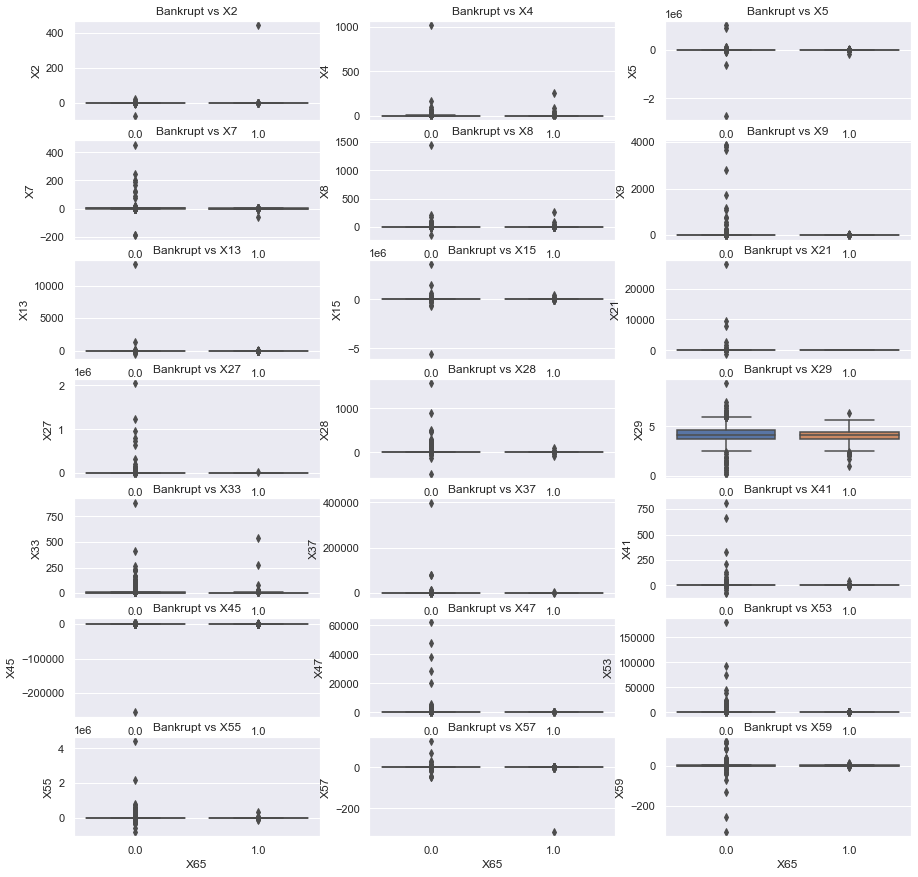

```python
fig, saxis = plt.subplots(7, 3,figsize=(15,15))
for i in range(3):
    sns.boxplot(x = "X65", y=year1.columns[i+1], data=year1, ax=saxis[0,i])
    saxis[0,i].set_title(f"Bankrupt vs {year1.columns[i+1]}")

for i in range(3):
    sns.boxplot(x = "X65", y=year1.columns[i+4], data=year1, ax=saxis[1,i])
    saxis[1,i].set_title(f"Bankrupt vs {year1.columns[i+4]}")

for i in range(3):
    sns.boxplot(x = "X65", y=year1.columns[i+7], data=year1, ax=saxis[2,i])
    saxis[2,i].set_title(f"Bankrupt vs {year1.columns[i+7]}")

for i in range(3):
    sns.boxplot(x = "X65", y=year1.columns[i+10], data=year1, ax=saxis[3,i])
    saxis[3,i].set_title(f"Bankrupt vs {year1.columns[i+10]}")
for i in range(3):
    sns.boxplot(x = "X65", y=year1.columns[i+13], data=year1, ax=saxis[4,i])
    saxis[4,i].set_title(f"Bankrupt vs {year1.columns[i+13]}")

for i in range(3):
    sns.boxplot(x = "X65", y=year1.columns[i+16], data=year1, ax=saxis[5,i])
    saxis[5,i].set_title(f"Bankrupt vs {year1.columns[i+16]}")

for i in range(3):
    sns.boxplot(x = "X65", y=year1.columns[i+19], data=year1, ax=saxis[6,i])
    saxis[6,i].set_title(f"Bankrupt vs {year1.columns[i+19]}")
```

We plot again the correlation matrix to proove that our model are not highly correlated

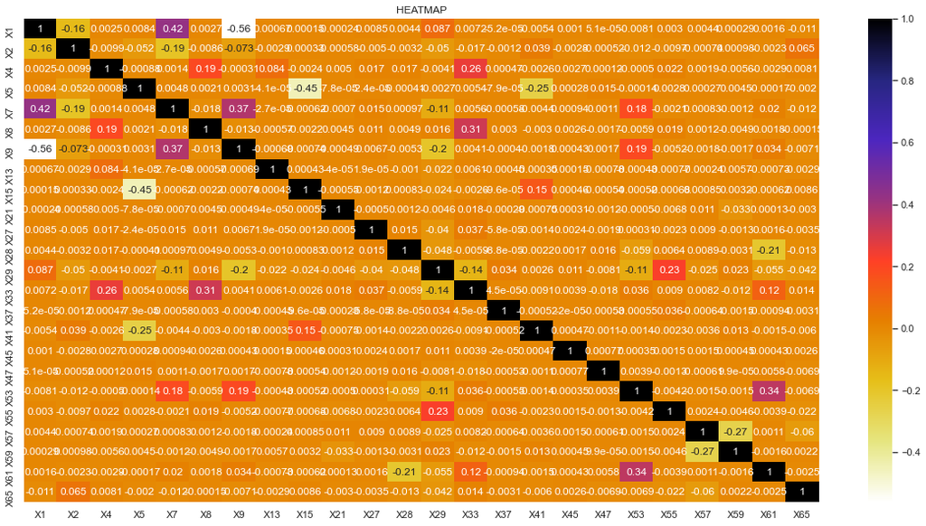

```python
corr2 = year1.corr()
plt.figure(figsize=(20,10))
ax = plt.axes()
sns.heatmap(corr2, annot=True,ax=ax, cmap=plt.cm.CMRmap_r)
ax.set_title("HEATMAP")
plt.show()
```

```python
year1.describe()
```

|  | X1 | X2 | X4 | X5 | X7 | X8 | X9 | X13 | X15 | X21 | ... | X37 | X41 | X45 | X47 | X53 | X55 | X57 | X59 | X61 | X65 |
| --- | --- | --- | --- | --- | --- | --- | --- | --- | --- | --- | --- | --- | --- | --- | --- | --- | --- | --- | --- | --- | --- |
| count | 7027.000000 | 7027.000000 | 7027.000000 | 7.027000e+03 | 7027.000000 | 7027.000000 | 7027.000000 | 7027.000000 | 7.027000e+03 | 7027.000000 | ... | 7027.000000 | 7027.000000 | 7027.000000 | 7027.000000 | 7027.000000 | 7.027000e+03 | 7027.000000 | 7027.000000 | 7027.000000 | 7027.000000 |
| mean | 0.034660 | 0.560215 | 2.629143 | -2.631672e+02 | 0.313876 | 2.623996 | 5.552855 | 2.093345 | 1.802696e+03 | 10.367516 | ... | 173.453694 | 0.604475 | -30.208158 | 86.752262 | 98.720579 | 8.855693e+03 | 0.193243 | 0.277829 | 15.642228 | 0.038566 |
| std | 4.564529 | 5.348941 | 13.229022 | 3.705348e+04 | 8.351490 | 18.675013 | 101.988190 | 159.699448 | 8.391038e+04 | 366.026602 | ... | 4951.382074 | 13.751817 | 3059.311298 | 1129.552631 | 2778.619803 | 7.247527e+04 | 4.343737 | 6.338698 | 261.144719 | 0.192571 |
| min | -256.890000 | -72.162000 | 0.000000 | -2.722100e+06 | -189.560000 | -141.410000 | 0.000005 | -607.420000 | -5.611900e+06 | -1325.000000 | ... | -525.520000 | -77.791000 | -256230.000000 | 0.000000 | -130.470000 | -8.004700e+05 | -315.370000 | -327.970000 | 0.000016 | 0.000000 |
| 25% | 0.021208 | 0.296760 | 1.064100 | -4.462850e+01 | 0.028037 | 0.447340 | 1.037250 | 0.038073 | 3.436150e+02 | 1.059400 | ... | 2.446500 | 0.035342 | 0.091121 | 18.391000 | 0.716905 | 9.712000e+01 | 0.056814 | 0.000000 | 4.834250 | 0.000000 |
| 50% | 0.075790 | 0.483090 | 1.505200 | -5.575300e+00 | 0.090177 | 1.022100 | 1.206000 | 0.080830 | 9.262300e+02 | 1.218200 | ... | 20.871000 | 0.090120 | 0.392540 | 39.418000 | 1.192200 | 1.604800e+03 | 0.175820 | 0.028451 | 7.046300 | 0.000000 |
| 75% | 0.160240 | 0.680170 | 2.476050 | 3.769500e+01 | 0.188880 | 2.286700 | 2.133150 | 0.144955 | 2.166000e+03 | 2.040450 | ... | 173.453694 | 0.212935 | 1.142300 | 69.501500 | 2.056800 | 5.955900e+03 | 0.351895 | 0.274140 | 10.775500 | 0.000000 |
| max | 94.280000 | 441.500000 | 1017.800000 | 9.909000e+05 | 453.770000 | 1452.200000 | 3876.100000 | 13315.000000 | 3.599100e+06 | 27900.000000 | ... | 398920.000000 | 813.140000 | 5986.800000 | 62233.000000 | 180440.000000 | 4.398400e+06 | 126.670000 | 119.580000 | 21110.000000 | 1.000000 |

8 rows × 24 columns

We kept the columns :

X1 :net profit / total assets X2: total liabilities / total assets X4: current assets / short-term liabilities X5: [(cash + short-term securities + receivables - short-term liabilities) / (operating expenses - depreciation)] *365 X7 :EBIT / total assets X8: book value of equity / total liabilities X9: sales / total assets X13 : (gross profit + depreciation) / sales X15: (total liabilities* 365) / (gross profit + depreciation) X21: sales (n) / sales (n-1) X27: profit on operating activities / financial expenses X28: working capital / fixed assets X29 :logarithm of total assets X33: operating expenses / short-term liabilities X37 :(current assets - inventories) / long-term liabilities X41: total liabilities / ((profit on operating activities + depreciation) *(12/365)) X45: net profit / inventory X47: (inventory* 365) / cost of products sold X53 :equity / fixed assets X55 :working capital X57 :(current assets - inventory - short-term liabilities) / (sales - gross profit - depreciation) X59: long-term liabilities / equity X61: sales / receivables

## Data Modeling : Prediction Model for columns X65

```python
X = year1.iloc[: ,:-1]
```

```python
Y = year1.iloc[:,-1]
```

```python
X_train, X_test, Y_train, Y_test = train_test_split(X,Y,test_size=0.33)
```

```python
print(X_train.shape)
print(X_test.shape)
print(Y_train.shape)
print(Y_test.shape)
```

```
(4708, 23)
(2319, 23)
(4708,)
(2319,)
```

# 1st Model : Random Forest

```python
from sklearn.ensemble import RandomForestClassifier
rf = RandomForestClassifier(n_estimators = 5, criterion = 'entropy')
rf.fit(X_train,Y_train)
```

```
RandomForestClassifier(criterion='entropy', n_estimators=5)
```

```python
y_pred=rf.predict(X_test)
```

```python
from sklearn import metrics
a =metrics.accuracy_score(Y_test, y_pred)
print("Accuracy:",metrics.accuracy_score(Y_test, y_pred))
```

```
Accuracy: 0.969383354894351
```

# 2nd Model : Logistic Regression

```python
from sklearn.linear_model import LogisticRegression
lr= LogisticRegression(solver='liblinear', random_state=0)
lr.fit(X_train,Y_train)
y_pred_lr=lr.predict(X_test)
b=metrics.accuracy_score(Y_test, y_pred_lr)
print("Accuracy:",metrics.accuracy_score(Y_test, y_pred_lr))
```

```
Accuracy: 0.9586028460543338
```

# 3rd Model : Decision Tree

```python
from sklearn.tree import DecisionTreeClassifier
clf = DecisionTreeClassifier()
clf = clf.fit(X_train,Y_train)
y_pred_clf = clf.predict(X_test)
c=metrics.accuracy_score(Y_test, y_pred_clf)
print("Accuracy:",metrics.accuracy_score(Y_test, y_pred_clf))
```

```
Accuracy: 0.9499784389823199
```

# 4th Model : Bagging

```python
from sklearn.svm import SVC
from sklearn.ensemble import BaggingClassifier
clfbg = BaggingClassifier(base_estimator=SVC(),n_estimators=10, random_state=0)
clfbg.fit(X_train, Y_train)
y_pred_bg = clfbg.predict(X_test)
d=metrics.accuracy_score(Y_test, y_pred_bg)
print("Accuracy:",metrics.accuracy_score(Y_test, y_pred_bg))
```

```
Accuracy: 0.963777490297542
```

# 5th Model : Gradient Boosting

```python
from sklearn.ensemble import GradientBoostingClassifier
clfb = GradientBoostingClassifier(n_estimators=100, learning_rate=1.0, max_depth=1, random_state=0)
clfb.fit(X_train, Y_train)
y_pred_b = clfb.predict(X_test)
f=metrics.accuracy_score(Y_test, y_pred_b)
print("Accuracy:",metrics.accuracy_score(Y_test, y_pred_b))
```

```
Accuracy: 0.9478223372143165
```

# 6th Model : KNN

```python
from sklearn.neighbors import KNeighborsClassifier
knn = KNeighborsClassifier(n_neighbors=2)
```

```python
knn.fit(X_train, Y_train)
y_pred_knn = knn.predict(X_test)
```

```python
g=metrics.accuracy_score(Y_test, y_pred_knn)
print("Accuracy:",metrics.accuracy_score(Y_test, y_pred_knn))
```

```
Accuracy: 0.9629150495903407
```

# Comparison of the Models

```
<BarContainer object of 6 artists>
```

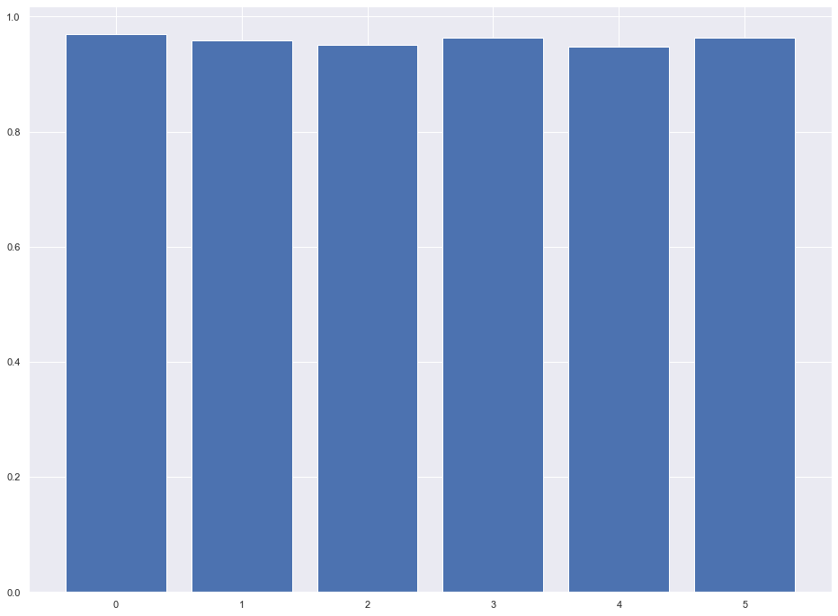

```python
plt.figure(figsize=(16,12))
plt.bar(range(6), [a, b, c, d, f, g])
```

The best model to predict our dataset is the 1st Model : Random Forest, with an accuracy of 0.9693

Now we would like to transform our model to an API. The main idea with this api is to create an Html Website, where the user can enter his parameters about his company and then our model will try to predict if his company is going to bankructy or not.